# R Intro

## Factor

A factor is useful to create categorical variables, that is very common in statistical analyses, such as the Anova.

```r
data <- factor(c("small", "medium", "large"))
```

[output not shown]

## Matrix

A matrix is bidimensional arrangement of **vectors**, where the vectors need to be of the same type, that is, two or more numeric vectors, or two or more character vectors.

```r
matx <- matrix(1:45, nrow = 15)
rownames(matx) <-  LETTERS[1:15]
colnames(matx) <- c("Sample01", "Sample02", "Sample03")
```

```r
matx # Inspect the matrix
```

```
##   Sample01 Sample02 Sample03
## A        1       16       31
## B        2       17       32
## C        3       18       33
## D        4       19       34
## E        5       20       35
## F        6       21       36
## G        7       22       37
## H        8       23       38
## I        9       24       39
## J       10       25       40
## K       11       26       41
## L       12       27       42
## M       13       28       43
## N       14       29       44
## O       15       30       45
```

```r
class(matx) # Ask which kind of data is?
```

```
## [1] "matrix"
```

```r
matx[, 1] # We can use brackets to select a specific column
```

```
##  A  B  C  D  E  F  G  H  I  J  K  L  M  N  O
##  1  2  3  4  5  6  7  8  9 10 11 12 13 14 15
```

```r
matx[1, ] # We can use brackets to select a specific row
```

```
## Sample01 Sample02 Sample03
##        1       16       31
```

```r
head(matx)
```

```
##   Sample01 Sample02 Sample03
## A        1       16       31
## B        2       17       32
## C        3       18       33
## D        4       19       34
## E        5       20       35
## F        6       21       36
```

```r
tail(matx)
```

```
##   Sample01 Sample02 Sample03
## J       10       25       40
## K       11       26       41
## L       12       27       42
## M       13       28       43
## N       14       29       44
## O       15       30       45
```

```r
#fix(matx)
str(matx)
```

```
##  int [1:15, 1:3] 1 2 3 4 5 6 7 8 9 10 ...
##  - attr(*, "dimnames")=List of 2
##   ..$ : chr [1:15] "A" "B" "C" "D" ...
##   ..$ : chr [1:3] "Sample01" "Sample02" "Sample03"
```

```r
summary(matx)
```

```
##     Sample01       Sample02       Sample03
##  Min.   : 1.0   Min.   :16.0   Min.   :31.0
##  1st Qu.: 4.5   1st Qu.:19.5   1st Qu.:34.5
##  Median : 8.0   Median :23.0   Median :38.0
##  Mean   : 8.0   Mean   :23.0   Mean   :38.0
##  3rd Qu.:11.5   3rd Qu.:26.5   3rd Qu.:41.5
##  Max.   :15.0   Max.   :30.0   Max.   :45.0
```

In general when we are exploring our data for example using **head()** the function will return only the 6 first rows of our matrix, however, we can add another argument into the function. For example, **head(matx, 10)**, just add the number 10 after the comma adn is possible to see the first 10 lines. This simple operation is useful specially when our matrix is large **>500 rows**.

## Data frame

The difference between a matrix and a data frame is that a data frame can handle different types of vectors. You can explore more about the data frames asking R **?data.frame**.

```r
df <- data.frame(species = c("rufus", "cristatus", "albogularis", "paraguayae"), habitat = factor(c("forest", "savanna", "urban", "transition")), high = c(10, 2, 7, 4), distance = c(3, 9, 5, 6))
```

```r
class(df)
```

```
## [1] "data.frame"
```

```r
matx2 <- as.data.frame(matx) # We can also transform our matrix to a data frame
class(matx2)
```

```
## [1] "data.frame"
```

```r
str(df)
```

```
## 'data.frame':    4 obs. of  4 variables:
##  $ species : Factor w/ 4 levels "albogularis",..: 4 2 1 3
##  $ habitat : Factor w/ 4 levels "forest","savanna",..: 1 2 4 3
##  $ high    : num  10 2 7 4
##  $ distance: num  3 9 5 6
```

```r
#fix(df)
#edit(df)
```

## List

The list is an object that consists of an assembly of objects sorted in a hierarchical way. Here we will use the data previously created.

```r
lst <- list(data, df, matx)
```

```r
str(lst)
```

```
## List of 3
##  $ : Factor w/ 3 levels "large","medium",..: 3 2 1
##  $ :'data.frame':    4 obs. of  4 variables:
##   ..$ species : Factor w/ 4 levels "albogularis",..: 4 2 1 3
##   ..$ habitat : Factor w/ 4 levels "forest","savanna",..: 1 2 4 3
##   ..$ high    : num [1:4] 10 2 7 4
##   ..$ distance: num [1:4] 3 9 5 6
##  $ : int [1:15, 1:3] 1 2 3 4 5 6 7 8 9 10 ...
##   ..- attr(*, "dimnames")=List of 2
##   .. ..$ : chr [1:15] "A" "B" "C" "D" ...
##   .. ..$ : chr [1:3] "Sample01" "Sample02" "Sample03"
```

```r
class(lst)
```

```
## [1] "list"
```

Now, inspect the objects that are stored into our object **lst**. To do this, we just need to use two brackets **[[]]**.

```r
lst[[1]]
```

```
## [1] small  medium large
## Levels: large medium small
```

```r
lst[[2]]
```

```
##       species    habitat high distance
## 1       rufus     forest   10        3
## 2   cristatus    savanna    2        9
## 3 albogularis      urban    7        5
## 4  paraguayae transition    4        6
```

```r
lst[[3]]
```

```
##   Sample01 Sample02 Sample03
## A        1       16       31
## B        2       17       32
## C        3       18       33
## D        4       19       34
## E        5       20       35
## F        6       21       36
## G        7       22       37
## H        8       23       38
## I        9       24       39
## J       10       25       40
## K       11       26       41
## L       12       27       42
## M       13       28       43
## N       14       29       44
## O       15       30       45
```

# Install and load packages

Although R is a programming language, it is also possible to use different auxiliary packages that are available for free to download and to install in our computers. Install new packages into R is easy and just needs a simple function **install.packages()**. For more information of how to install new packages, you just need to ask R, using **?install.packages**

```r
install.packages("PACKAGE NAME")
```

The reverse function is **remove.packages()**.

Most of the time, we do not remember if we already have a package installed in our computer, so if we are tired and do not want to go to our R folder and check if the package is in fact installed, we can use the next command.

```r
if ( ! ("PACKAGE NAME" %in% installed.packages())) {install.packages("PACKAGE NAME", dependencies = T)}
```

To load an installed package you can just type, **library() or require()**

```r
library("PACKAGE NAME")
require("PACKAGE NAME")
```

# R as a calculator

R can be used as a calculator, for example, we can use the information created before to make some arithmetic operations.

```r
b[4]+seq_test[10]
```

```
## [1] 23
```

```r
b[4]*seq_test[10]
```

```
## [1] 76
```

```r
seq_test[5]/df[3, 3]
```

```
## [1] 1.285714
```

```r
matx[, 3][4]-df[4, 4]
```

```
##  D
## 28
```

```r
seq_test^7
```

```
##  [1]         1      2187     78125    823543   4782969  19487171  62748517
##  [8] 170859375 410338673 893871739
```

```r
seq_test*7
```

```
##  [1]   7  21  35  49  63  77  91 105 119 133
```

```r
seq_test+7
```

```
##  [1]  8 10 12 14 16 18 20 22 24 26
```

```r
seq_test-7
```

```
##  [1] -6 -4 -2  0  2  4  6  8 10 12
```

```r
mean(seq_test)
```

```
## [1] 10
```

```r
max(seq_test)
```

```
## [1] 19
```

```r
min(seq_test)
```

```
## [1] 1
```

```r
sum(seq_test)
```

```
## [1] 100
```

```r
log(seq_test)
```

```
##  [1] 0.000000 1.098612 1.609438 1.945910 2.197225 2.397895 2.564949
##  [8] 2.708050 2.833213 2.944439
```

```r
sqrt(seq_test)
```

```
##  [1] 1.000000 1.732051 2.236068 2.645751 3.000000 3.316625 3.605551
##  [8] 3.872983 4.123106 4.358899
```

```r
cor(matx[, 1], matx[, 2])
```

```
## [1] 1
```

# Data import/export

As indicated before, in R you can handle different information (from vector to data frames) and basically most of our data is stored in an Excel spreadsheet or in files that have the extension of **.csv** (comma-separated values file) or **.txt** (Text X Text or text file that contains unformatted text).

Most of these files are imported in R are **data frames**, but, as we were practicing, we now have the tools to handle or transform the information into different objects.

The function to import data to R is simple **read.table()** or **read.csv()**, and using these simple functions, you can import the data and transform it in other kind of objects So, lets practice!

```r
dat <- read.table("Data/Sample.txt")

dat2 <- read.table("Data/Sample.txt", row.names = 1, header = TRUE)

dat3 <- read.csv("Data/Sample.csv")
```

```r
class(dat)
```

```
## [1] "data.frame"
```

```r
class(dat2)
```

```
## [1] "data.frame"
```

```r
class(dat3)
```

```
## [1] "data.frame"
```

```r
dat3Sample <- dat3[1:50, 1:4]
dim(dat3Sample)
```

```
## [1] 50  4
```

```r
dat4 <- na.omit(as.matrix(read.csv("Data/Sample.csv", row.names = 1, header = TRUE)))
class(dat4)
```

```
## [1] "matrix"
```

```r
head(dat4, 10)
```

```
##     Longitude.x. Latitude.y.        PD SR      PSVs SR.1        vars
## 192       -108.5        26.5 0.3789908  3 0.7965072    3 0.004459021
## 222        -78.5        25.5 0.2167810  2 0.3536695    2 0.012361281
## 229       -107.5        24.5 0.2684503  2 0.7393375    2 0.012361281
## 230       -106.5        24.5 0.2684503  2 0.7393375    2 0.012361281
## 235       -101.5        24.5 0.2789230  2 0.8175072    2 0.012361281
## 245       -106.5        23.5 0.2684503  2 0.7393375    2 0.012361281
## 246       -105.5        23.5 0.2684503  2 0.7393375    2 0.012361281
## 247       -104.5        23.5 0.2684503  2 0.7393375    2 0.012361281
## 248       -103.5        23.5 0.2684503  2 0.7393375    2 0.012361281
## 250       -101.5        23.5 0.2789230  2 0.8175072    2 0.012361281
##         aMRD     aMDR      aAGES
## 192 17.66667 14.27362 0.05628246
## 222 12.50000 26.88631 0.01707297
## 229 18.50000 14.49822 0.05489227
## 230 18.50000 14.49822 0.05489227
## 235 19.50000 17.25644 0.05057945
## 245 18.50000 14.49822 0.05489227
## 246 18.50000 14.49822 0.05489227
## 247 18.50000 14.49822 0.05489227
## 248 18.50000 14.49822 0.05489227
## 250 19.50000 17.25644 0.05057945
```

```r
dat4[1:20, 1:4]
```

```
##     Longitude.x. Latitude.y.        PD SR
## 192       -108.5        26.5 0.3789908  3
## 222        -78.5        25.5 0.2167810  2
## 229       -107.5        24.5 0.2684503  2
## 230       -106.5        24.5 0.2684503  2
## 235       -101.5        24.5 0.2789230  2
## 245       -106.5        23.5 0.2684503  2
## 246       -105.5        23.5 0.2684503  2
## 247       -104.5        23.5 0.2684503  2
## 248       -103.5        23.5 0.2684503  2
## 250       -101.5        23.5 0.2789230  2
## 251       -100.5        23.5 0.3817156  3
## 252        -99.5        23.5 0.3817156  3
## 255        -82.5        23.5 1.2950881 14
## 256        -81.5        23.5 0.5936688  5
## 257        -80.5        23.5 0.2961977  2
## 261       -106.5        22.5 0.2684503  2
## 262       -105.5        22.5 0.2684503  2
## 263       -104.5        22.5 0.2684503  2
## 264       -103.5        22.5 0.2684503  2
## 265       -102.5        22.5 0.2684503  2
```

You can also import your data using the same functions, but without specifying the address. Notice that we do not recomend this procedure as you can’t control the **directory structure**, but is useful when you just are exploring data.

You can also save your data from R using the function **write.table** or **write.csv**. Lets save the dat3Sample. Notice that always we need to specify the correct address, in our case we will save the data in the subolder **Data**.

```r
is.na(dat3Sample)
write.csv(dat3Sample, file = "Data/dat3Sample.csv")
```

# Phylogenetic data

To study biodiversity is important to first understand the data and one common data used now is the phylogentic data or phylogenetic trees that describe the evolutionary relationships between and among lineages. From here until the end of this short tutorial we will try to explain the basics of how to import/export and handle phylogenetic information. You can find extra information at https://www.r-phylo.org/wiki/HowTo/Table_of_Content e http://www.mpcm-evolution.org/practice/online-practical-material-chapter-2.

## Formats

The two most common formats in which the phylogenies are stored are the Newick and Nexus (Maddison et al. 1997).

The Newick format represent the phylogenetic relationships as **“(”, “,” and “:”**, so the species relationships can be represented as follows:

```r
((A:10,B:9)D:5,C:15)F;
```

Using this notation, the parenthesis links the lineages to a specific node of the tree and the comma **“,”** separates the lineages that descend from that node. The colon punctuation **“:”** can be used after the name of the node and the subsequent numeric values represent the branch lenght. Finally, the semicolon punctuation **“;”** indicate the end of the phylogenetic tree.

Now we can see how this format works, but first, check if we have the R packages for this purpose.

```r
if ( ! ("ape" %in% installed.packages())) {install.packages("ape", dependencies = T)}
```

```r
require(ape)
```

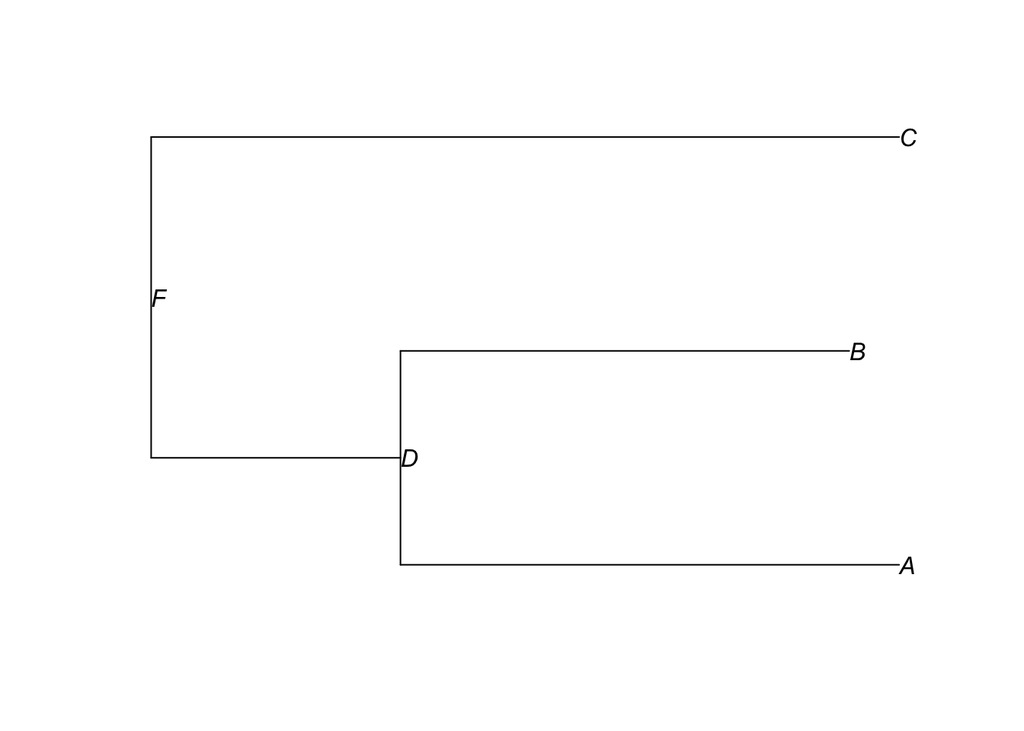

```r
## Here we will create a phylogenetic tree in Newick format
newick_tree <- "((A:10,B:9)D:5,C:15)F;"

## Read the tre
newick_tree <- read.tree(text = newick_tree)

## And now we can plot the phylogentic tree
plot(newick_tree, show.node.label = TRUE)
```

The other format is the **Nexus**, and after some time we can say the Nexus format have more flexibility for working. An example of a Nexus format is as follow:

```r
#NEXUS
BEGIN TAXA;
DIMENSIONS NTAXA=3;
TaxLabels A B C;
END;
BEGIN TREES;
TREE=((A:10,B:9)D:5,C:15)F;
END;
```

```r
## First create a Nexus file in the working directory
cat(
 "#NEXUS
 BEGIN TAXA;
 DIMENSIONS NTAXA=3;
 TaxLabels A B C;
 END;
 BEGIN TREES;
 TREE=((A:10,B:9)D:5,C:15)F;
 END;",
file = "Data/Nexus_tree.nex"
)
```

```r
## Now read the phylogenetic tree, but look that instead of using read.tree we are using read.nexus
nexus_tree <- read.nexus("Data/Nexus_tree.nex")
```

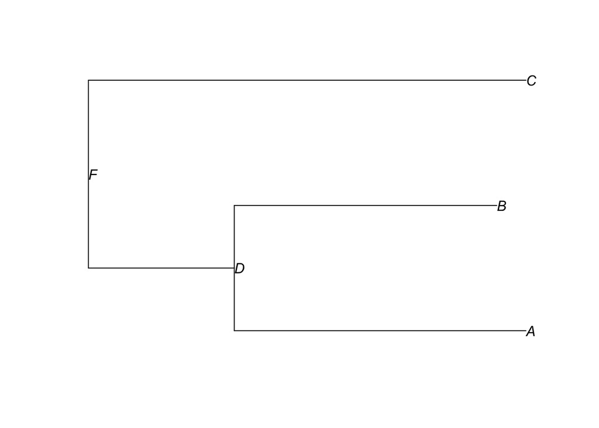

```r
## lets plot the example
plot(nexus_tree, show.node.label = TRUE)
```

Now lets inspect our phylogenetic trees.

```r
str(nexus_tree)
```

```
## List of 5
##  $ edge       : int [1:4, 1:2] 4 5 5 4 5 1 2 3
##  $ edge.length: num [1:4] 5 10 9 15
##  $ Nnode      : int 2
##  $ node.label : chr [1:2] "F" "D"
##  $ tip.label  : chr [1:3] "A" "B" "C"
##  - attr(*, "class")= chr "phylo"
##  - attr(*, "order")= chr "cladewise"
```

```r
nexus_tree$tip.label
```

```
## [1] "A" "B" "C"
```

If we want to know about the branch lenght of the tree we just need to select **edge.lenght**

```r
nexus_tree$edge.length
```

```
## [1]  5 10  9 15
```

An important component of a phylo object is the matrix called **edge**. In this matrix, each **row** represents a **branch** in the tree and the **first column** shows the index of the ancestral node of the branch and the **second column** shows the descendant node of that branch. Lets inspect!

```r
nexus_tree$edge
```

```
##      [,1] [,2]
## [1,]    4    5
## [2,]    5    1
## [3,]    5    2
## [4,]    4    3
```

We know, it is a little hard to follow even with small trees as the example, but, if we plot the phylogenetic tree, the information within it is easier to understand.

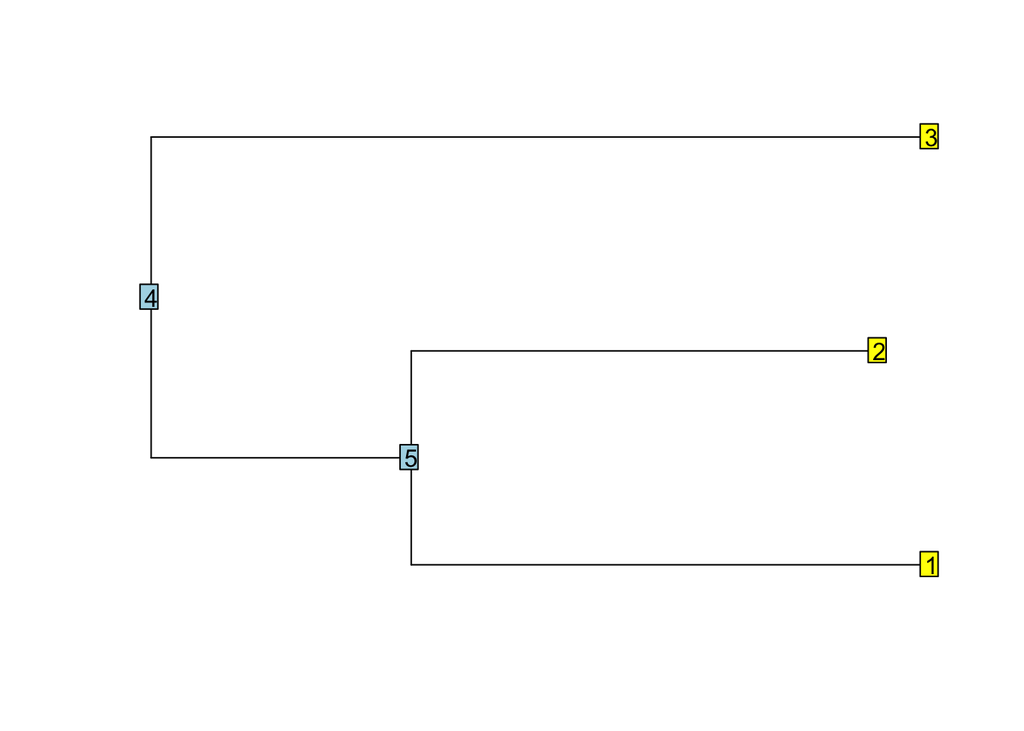

```r
# Lets plot the tree
plot(nexus_tree, show.tip.label = FALSE)
# Add the internal nodes
nodelabels()
# Add the tips or lineages
tiplabels()
```

Finally, the phylogenies can also be imported in form of a list and in phylogenetic comparative methods this list of phylogenies is called **multiPhylo**, and we can import/export these multiPhylos in the two formats.

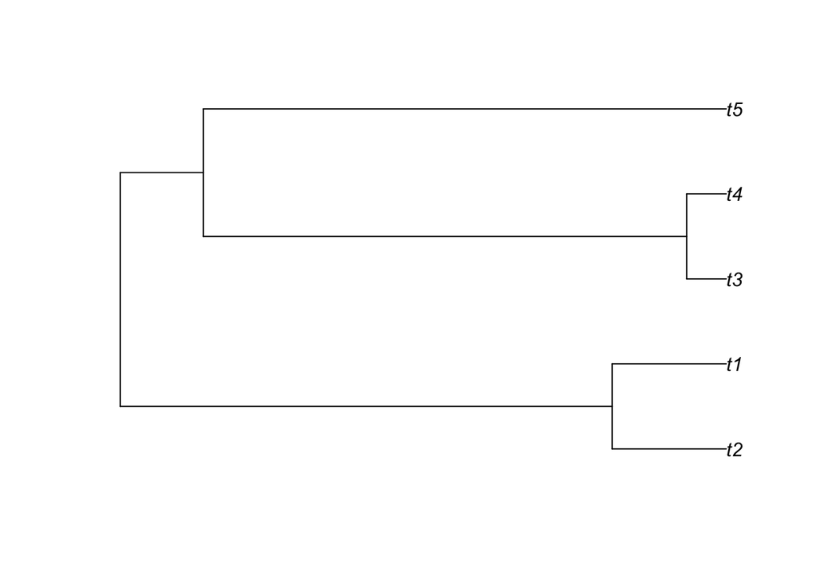

```r
# Simulate 10 phylogenies, each one with 5 species
multitree <- replicate(10, rcoal(5), simplify = FALSE)
# Store the list of trees as a multiPhylo object
class(multitree) <- "multiPhylo"

# Plot a single tree from the 10
plot(multitree[[10]])
```

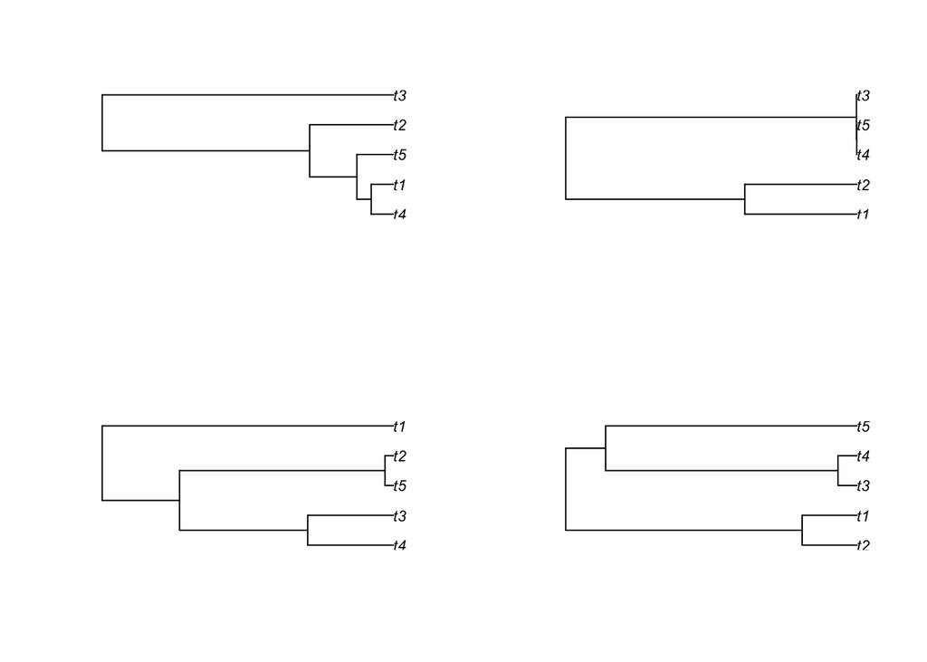

```r
par(mfrow = c(2, 2))
plot(multitree[[1]])
plot(multitree[[3]])
plot(multitree[[7]])
plot(multitree[[10]])
```

```r
# Exporting the phylogenies as a single Newick file.
write.tree(phy = multitree, file = "Data/multitree_example_newick.txt")
multitree_example_newick <- read.tree("Data/multitree_example_newick.txt")
multitree_example_newick
```

```
## 10 phylogenetic trees
```

```r
# Exporting the phylogenies as a single Nexus file.
write.nexus(phy = multitree, file = "Data/multitree_example_nexus.nex")
multitree_example_nexus <- read.nexus("Data/multitree_example_nexus.nex")
multitree_example_nexus
```

```
## 10 phylogenetic trees
```

# Gentle intro to loops

In programming one of the most important tool is the **loop** AKA **for**. Basically, a loop runs for a **n** number of steps in a previously defined statement.

The basic syntax struture of a loop is:

```r
for (variable in vector) {
  execute defined statements
}
```

When we are programming it is common to use the loop variable **i** to determine the number of steps. Why not other letter?, well **i** is the first letter of the word **iteration** —duh! Anyway, you can use any letter or word as a loop variable.

So, lets take a look.

```r
for (i in 1:10){
  cat(i, sep = '')
}
```

```
## 12345678910
```

Notice that the number of steps is determined by the loop variable and in this example is a sequence of steps from 1 to 10, that correspond to the second element of the **for loop**, the **vector**.

You can modify the previous statement to obtain different results, for example:

```r
for (i in 1:10){
  cat(i, sep = '\n')
}
```

```
## 1
## 2
## 3
## 4
## 5
## 6
## 7
## 8
## 9
## 10
```

Or using a previous object:

```r
for (i in 5:length(ex)){
  cat(i, sep = '\n')
}
```

```
## 5
## 6
## 7
## 8
## 9
## 10
```

Or to make calculations

```r
for (i in 5:length(ex)){
  b2 <- b^2
  b3 <- b*2
  b4 <- b+10
}
```

```r
BioSciNames <- c("Jeannine", "Jesús", "Bailey", "Kalli", "Ariadna", "Samantha", "Maxell",
                 "Sara", "Nicholas", "Carmen", "Ashley", "Mikkel", "Shana", "Kirsten",
                 "Lucy", "Joe", "Joshua")
```

```r
for (i in 3:length(BioSciNames)){
  cat("Hi,", BioSciNames[i], ", welcome to the first practice!","\n");
}
```

```
## Hi, Bailey , welcome to the first practice!
## Hi, Kalli , welcome to the first practice!
## Hi, Ariadna , welcome to the first practice!
## Hi, Samantha , welcome to the first practice!
## Hi, Maxell , welcome to the first practice!
## Hi, Sara , welcome to the first practice!
## Hi, Nicholas , welcome to the first practice!
## Hi, Carmen , welcome to the first practice!
## Hi, Ashley , welcome to the first practice!
## Hi, Mikkel , welcome to the first practice!
## Hi, Shana , welcome to the first practice!
## Hi, Kirsten , welcome to the first practice!
## Hi, Lucy , welcome to the first practice!
## Hi, Joe , welcome to the first practice!
## Hi, Joshua , welcome to the first practice!
```

We have covered basic aspects of R, from exploring and managing object to import/export data and basics into loops. We hope that this short tutorial can be useful not only for the **Biodiversity Sciences** course, but for your specific projects. Remember, practice, practice, practice!

# References

Maddison, D. R., Swofford, D. L. and Maddison, W. P. (1997). NEXUS: An Extensible File Format for Systematic Information. Systematic Biology 46, 590.